# Drzewo decyzyjne

Jakub Myśliwiec, Filip Twardy

## Przygotowanie danych

```r
ds = read.csv('data.csv')
head(ds)
```

```
##         id diagnosis radius_mean texture_mean perimeter_mean area_mean
## 1   842302         M       17.99        10.38         122.80    1001.0
## 2   842517         M       20.57        17.77         132.90    1326.0
## 3 84300903         M       19.69        21.25         130.00    1203.0
## 4 84348301         M       11.42        20.38          77.58     386.1
## 5 84358402         M       20.29        14.34         135.10    1297.0
## 6   843786         M       12.45        15.70          82.57     477.1
##   smoothness_mean compactness_mean concavity_mean concave.points_mean
## 1         0.11840          0.27760         0.3001             0.14710
## 2         0.08474          0.07864         0.0869             0.07017
## 3         0.10960          0.15990         0.1974             0.12790
## 4         0.14250          0.28390         0.2414             0.10520
## 5         0.10030          0.13280         0.1980             0.10430
## 6         0.12780          0.17000         0.1578             0.08089
##   symmetry_mean fractal_dimension_mean radius_se texture_se perimeter_se
```

[output cut: 34 more lines]

```r
dim(ds)
```

```
## [1] 569  33
```

```r
# removing last columns as it's full of NA values
ds = ds[-33]
dim(ds)
```

```
## [1] 569  32
```

```r
ds$diagnosis = as.factor(ds$diagnosis)
head(ds)
```

```
##         id diagnosis radius_mean texture_mean perimeter_mean area_mean
## 1   842302         M       17.99        10.38         122.80    1001.0
## 2   842517         M       20.57        17.77         132.90    1326.0
## 3 84300903         M       19.69        21.25         130.00    1203.0
## 4 84348301         M       11.42        20.38          77.58     386.1
## 5 84358402         M       20.29        14.34         135.10    1297.0
## 6   843786         M       12.45        15.70          82.57     477.1
##   smoothness_mean compactness_mean concavity_mean concave.points_mean
## 1         0.11840          0.27760         0.3001             0.14710
## 2         0.08474          0.07864         0.0869             0.07017
## 3         0.10960          0.15990         0.1974             0.12790
## 4         0.14250          0.28390         0.2414             0.10520
## 5         0.10030          0.13280         0.1980             0.10430
## 6         0.12780          0.17000         0.1578             0.08089
##   symmetry_mean fractal_dimension_mean radius_se texture_se perimeter_se
```

[output cut: 34 more lines]

## Drzewa klasyfikacyjne

```r
install.packages("tree", repos = "http://cran.us.r-project.org")
library(tree)
```

```r
diagnosis_tree <- tree(diagnosis ~ . - id - diagnosis, data = ds)
summary(diagnosis_tree)
```

```
##
## Classification tree:
## tree(formula = diagnosis ~ . - id - diagnosis, data = ds)
## Variables actually used in tree construction:
## [1] "perimeter_worst"      "concave.points_worst" "radius_se"
## [4] "texture_worst"        "symmetry_worst"       "smoothness_worst"
## [7] "radius_mean"          "smoothness_mean"
## Number of terminal nodes:  12
## Residual mean deviance:  0.09294 = 51.77 / 557
## Misclassification error rate: 0.01757 = 10 / 569
```

Jak widać spośród 32 cech, w predykcji udział bierze tylko 8: * perimeter_worst * concave.points_worst * radius_se * texture_worst * symetry_worst * smoothness_worst * radius_mean * smoothness_mean

Osiągnięty błąd na zbiorze treningowym jest bardzo dobry i wynosi poniżej 2%.

Drzewo jest całkiem małe jak na wielkość zbioru bo ma tylko 12 liści.

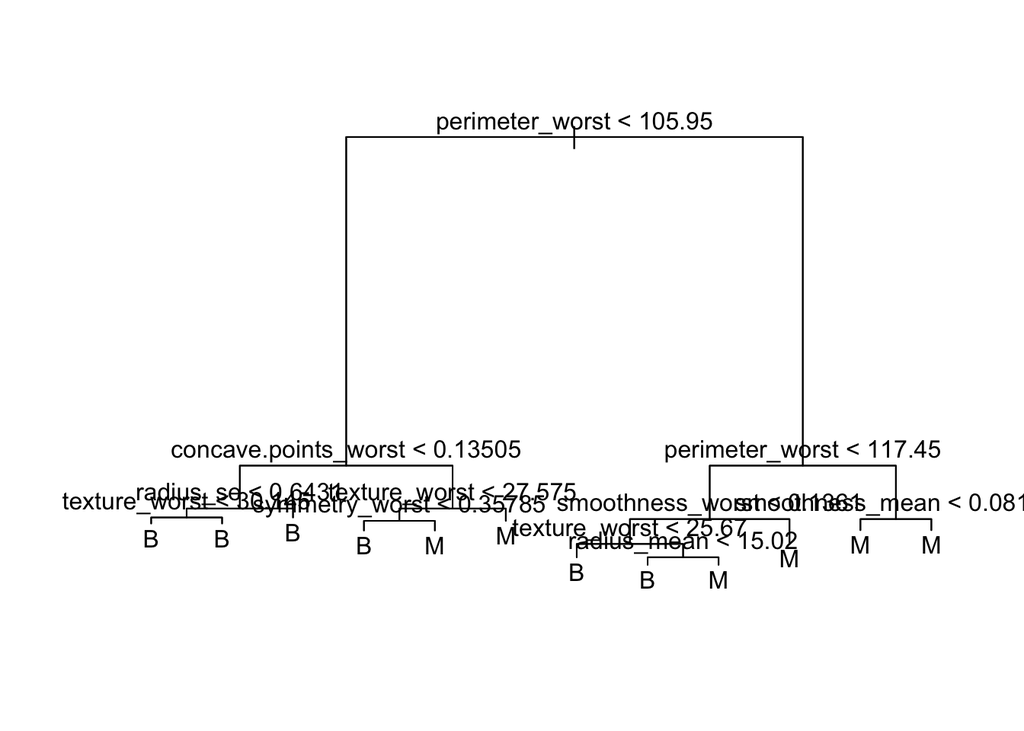

```r
plot(diagnosis_tree)
text(diagnosis_tree, pretty = 0)
```

```r
diagnosis_tree
```

```
## node), split, n, deviance, yval, (yprob)
##       * denotes terminal node
##
##  1) root 569 751.400 B ( 0.627417 0.372583 )
##    2) perimeter_worst < 105.95 345 135.500 B ( 0.950725 0.049275 )
##      4) concave.points_worst < 0.13505 320  43.010 B ( 0.987500 0.012500 )
##        8) radius_se < 0.6431 315  24.220 B ( 0.993651 0.006349 )
##         16) texture_worst < 30.145 273   0.000 B ( 1.000000 0.000000 ) *
##         17) texture_worst > 30.145 42  16.080 B ( 0.952381 0.047619 ) *
##        9) radius_se > 0.6431 5   6.730 B ( 0.600000 0.400000 ) *
##      5) concave.points_worst > 0.13505 25  34.620 M ( 0.480000 0.520000 )
##       10) texture_worst < 27.575 16  17.990 B ( 0.750000 0.250000 )
##         20) symmetry_worst < 0.35785 11   0.000 B ( 1.000000 0.000000 ) *
##         21) symmetry_worst > 0.35785 5   5.004 M ( 0.200000 0.800000 ) *
##       11) texture_worst > 27.575 9   0.000 M ( 0.000000 1.000000 ) *
##    3) perimeter_worst > 105.95 224 172.600 M ( 0.129464 0.870536 )
##      6) perimeter_worst < 117.45 57  78.860 M ( 0.473684 0.526316 )
##       12) smoothness_worst < 0.1361 34  37.100 B ( 0.764706 0.235294 )
##         24) texture_worst < 25.67 20   0.000 B ( 1.000000 0.000000 ) *
##         25) texture_worst > 25.67 14  19.120 M ( 0.428571 0.571429 )
##           50) radius_mean < 15.02 8   8.997 B ( 0.750000 0.250000 ) *
##           51) radius_mean > 15.02 6   0.000 M ( 0.000000 1.000000 ) *
##       13) smoothness_worst > 0.1361 23   8.227 M ( 0.043478 0.956522 ) *
##      7) perimeter_worst > 117.45 167  21.680 M ( 0.011976 0.988024 )
##       14) smoothness_mean < 0.08113 5   6.730 M ( 0.400000 0.600000 ) *
##       15) smoothness_mean > 0.08113 162   0.000 M ( 0.000000 1.000000 ) *
```

Można zauważyć kilka ciekawych zjawisk jak naprzykład to, że węzęł 8 został podzielony na liście 16 i 17, i oba te liście zostały sklasyfikowane jako Benign. Z punktu klasyfikacji wydaję się to nie potrzebne, ale pozwoliło to zooptymalizować *deviance*, bo w liściu 16, znalazły się same przypadki Benign, a w liściu 17 znajduję się kilka Malignant. Podobny przypadek mamy z węzłęm 7 i liśćmi 14 oraz 15.

### Błąd testowy

```r
set.seed(1)
n <- nrow(ds)
train <- sample(n, n / 2)
test <- -train
diagnosis_tree2 <- tree(diagnosis ~ . - id - diagnosis, data = ds, subset = train)
tree_class <- predict(diagnosis_tree2, newdata = ds[test,], type = "class")
table(tree_class, ds$diagnosis[test])
```

```
##
## tree_class   B   M
##          B 156   9
##          M  10 110
```

```r
mean(tree_class != ds$diagnosis[test])
```

```
## [1] 0.06666667
```

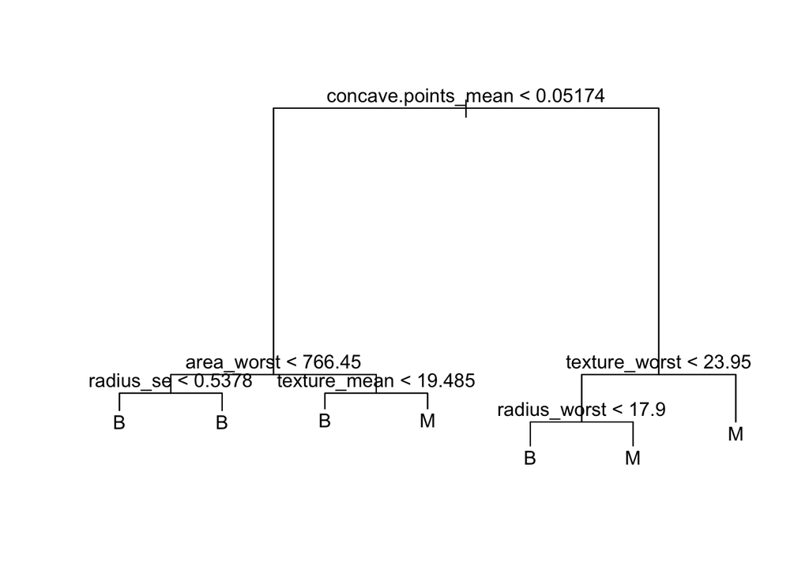

```r
plot(diagnosis_tree2)
text(diagnosis_tree2, pretty = 0)
```

```r
set.seed(1)
diagnosis_cv <- cv.tree(diagnosis_tree2, FUN = prune.misclass)
diagnosis_cv
```

```
## $size
## [1] 7 6 4 2 1
##
## $dev
## [1] 22 22 23 32 93
##
## $k
## [1] -Inf  0.0  1.5  5.0 75.0
##
## $method
## [1] "misclass"
##
## attr(,"class")
## [1] "prune"         "tree.sequence"
```

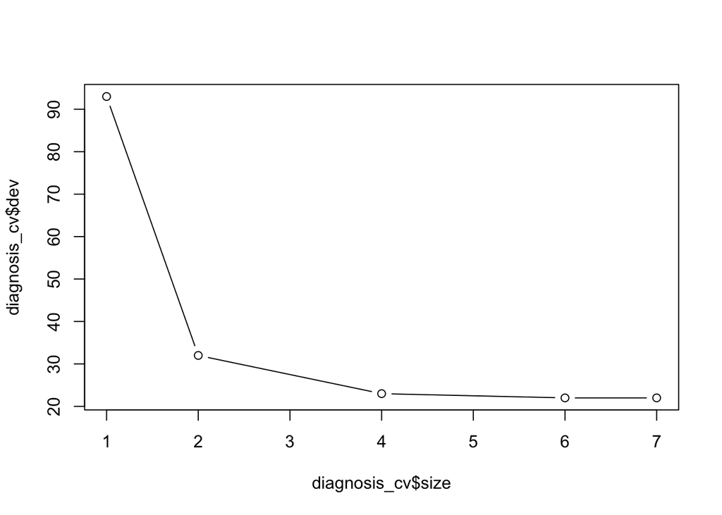

```r
plot(diagnosis_cv$size, diagnosis_cv$dev, type = "b")
```

Można zauważyć że drzewo minimalnie mniejsze - które ma 6 liści, ma taki sam błąd, więc możemy uprościć drzewo, zachowując taką samą skuteczność.

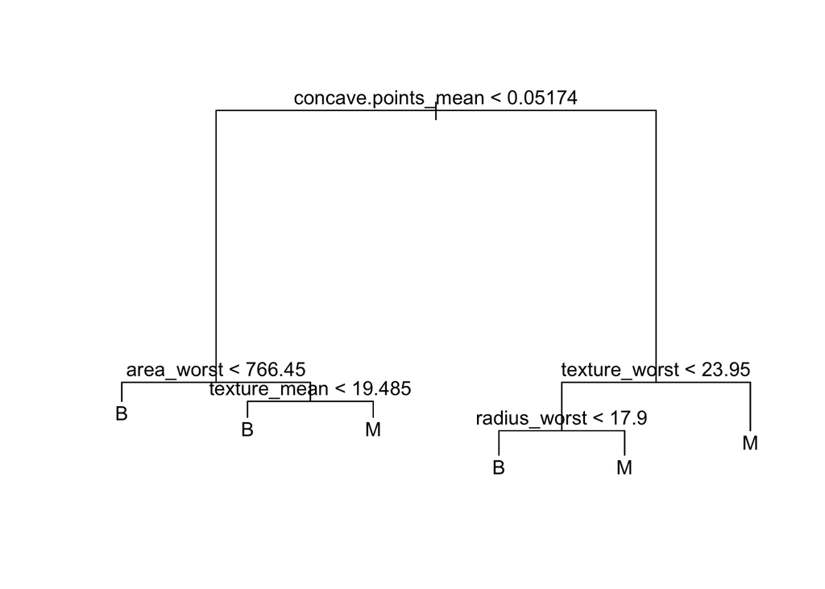

```r
size_opt <- 6
diagnosis_pruned <- prune.misclass(diagnosis_tree2, best = size_opt)
plot(diagnosis_pruned)
text(diagnosis_pruned, pretty = 0)
```

```r
pruned_class <- predict(diagnosis_pruned, newdata = ds[test,],
                        type = "class")
table(pruned_class, ds$diagnosis[test])
```

```
##
## pruned_class   B   M
##            B 156   9
##            M  10 110
```

```r
mean(pruned_class != ds$diagnosis[test])
```

```
## [1] 0.06666667
```

Jak widać zmniejszenie rozmiaru drzewa nie spowodowało wzrostu błędu, a dzięki temu otrzymaliśmy drzewo łatwiejsze w implementacji.

## Drzewo regresyjne

```r
radius_tree <- tree(radius_mean ~ . -id, data = ds)
summary(radius_tree)
```

```
##
## Regression tree:
## tree(formula = radius_mean ~ . - id, data = ds)
## Variables actually used in tree construction:
## [1] "area_mean"
## Number of terminal nodes:  8
## Residual mean deviance:  0.3677 = 206.3 / 561
## Distribution of residuals:
##     Min.  1st Qu.   Median     Mean  3rd Qu.     Max.
## -2.50900 -0.43430  0.00219  0.00000  0.43570  3.19800
```

Co ciekawe, otrzymaliśmy drzewo regresyjne, które bazuję tylko na jednym parametrze *area_mean*. Po głębszej analizie można zauważyć, że zmienne te są ze sobą dosyć mocno skorelowane.

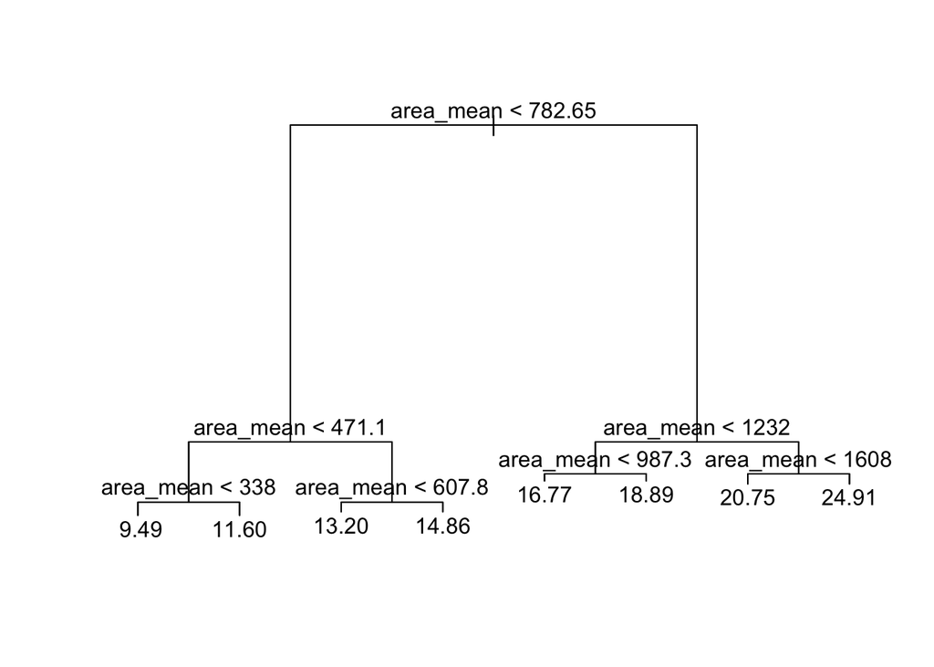

```r
plot(radius_tree)
text(radius_tree)
```

### Błąd testowy

```r
set.seed(1)
n <- nrow(ds)
train <- sample(n, n / 2)
test <- -train
radius_tree2 <- tree(radius_mean ~ . - id, data = ds, subset = train)
radius_pred <- predict(radius_tree2, newdata = ds[test,])
mean((radius_pred - ds$radius_mean[test])^2)
```

```
## [1] 0.3970225
```

```r
summary(radius_tree2)
```

```
##
## Regression tree:
## tree(formula = radius_mean ~ . - id, data = ds, subset = train)
## Variables actually used in tree construction:
## [1] "area_mean"      "perimeter_mean"
## Number of terminal nodes:  8
## Residual mean deviance:  0.3509 = 96.84 / 276
## Distribution of residuals:
##     Min.  1st Qu.   Median     Mean  3rd Qu.     Max.
## -2.39200 -0.47960  0.02713  0.00000  0.42130  2.01800
```

Jak widać drzewo regresyjnę nauczone na zbiorzę treningowym, będący podzbiorem poprzedniego, wykorzustuje dwa predykatory. Residuals są bardzo podobne w obu wypadkach, samo drzewo ma również taką samą ilość liści jak poprzednio.

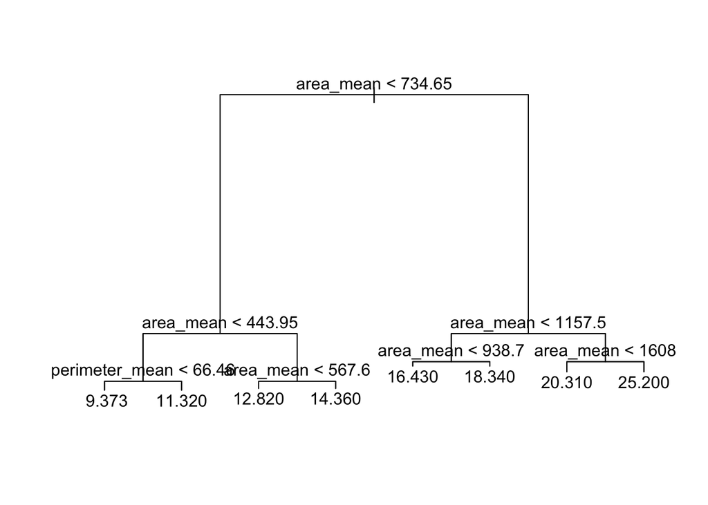

```r
plot(radius_tree2)
text(radius_tree2)
```

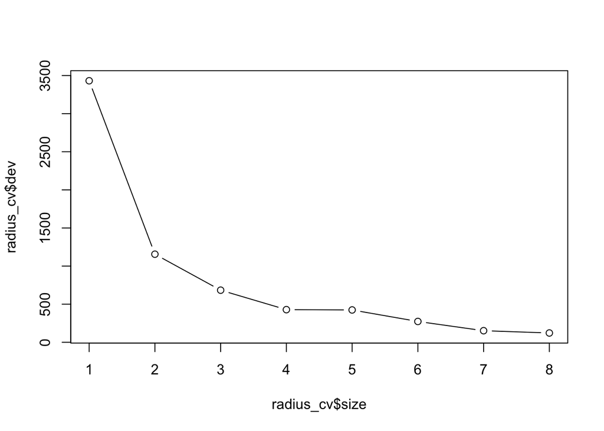

```r
radius_cv <- cv.tree(radius_tree2)
plot(radius_cv$size, radius_cv$dev, type = "b")
```

Jak widać żadnę poddrzewo nie ma lepszego lub takiego samego błędu, więc w tym wypadku nie opłaca się go zmniejszać dla ułatwienia interpretacji. Co więcej w naszym przypadku drzewo to jest i tak dość proste w interpretacji z racji na dosyć dużą korelację z predykatorem *area_mean*. Można bardzo szybko wysunąć wniosek, że czym większa *area*, to *radius* też musi być większy.

## Lasy losowe

Regresja.

```r
library(randomForest)
set.seed(2)
ds_rf <- randomForest(radius_mean ~ . -id - diagnosis, data = ds, subset = train,
                         importance = TRUE)
ds_pred_rf <- predict(ds_rf, newdata = ds[test,])
mean((ds_pred_rf - ds$radius_mean[test])^2)
```

```
## [1] 0.1889748
```

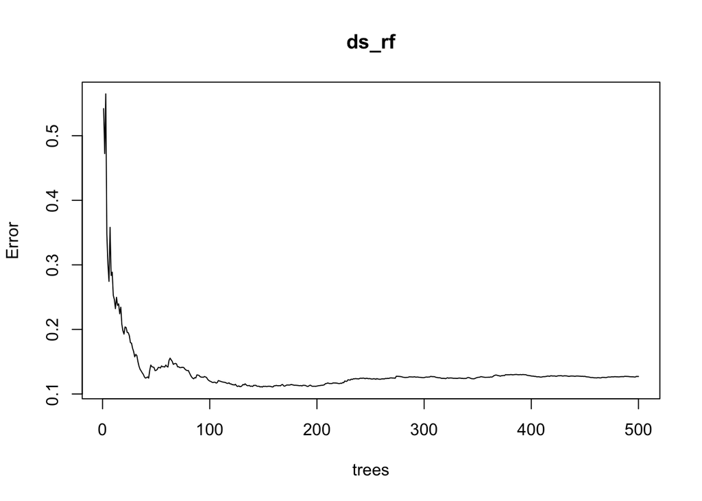

```r
plot(ds_rf)
```

Jak widzimy nie ma sensu przekraczać 50-60 liczby drzew ponieważ nasz błąd nie spada jakoś radykalnie.

```r
summary(ds_rf)
```

```
##                 Length Class  Mode
## call              5    -none- call
## type              1    -none- character
## predicted       284    -none- numeric
## mse             500    -none- numeric
## rsq             500    -none- numeric
## oob.times       284    -none- numeric
## importance       58    -none- numeric
## importanceSD     29    -none- numeric
## localImportance   0    -none- NULL
## proximity         0    -none- NULL
## ntree             1    -none- numeric
## mtry              1    -none- numeric
## forest           11    -none- list
## coefs             0    -none- NULL
## y               284    -none- numeric
## test              0    -none- NULL
## inbag             0    -none- NULL
## terms             3    terms  call
```

Klasyfikacja

```r
set.seed(2)
ds_rf <- randomForest(diagnosis ~ . - id, data = ds, subset = train,
                         importance = TRUE)
ds_pred_rf <- predict(ds_rf, newdata = ds[test,])
```

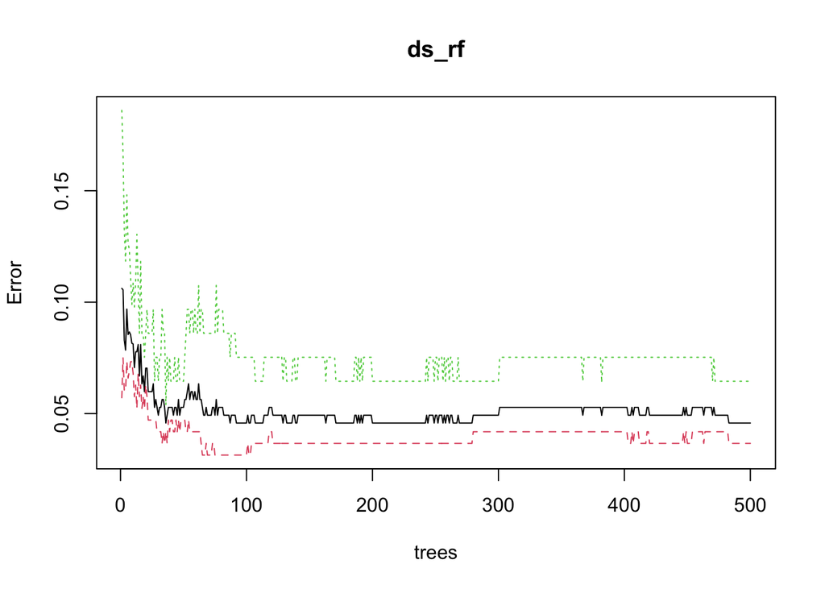

```r
plot(ds_rf)
```

```r
summary(ds_rf)
```

```
##                 Length Class  Mode
## call               5   -none- call
## type               1   -none- character
## predicted        284   factor numeric
## err.rate        1500   -none- numeric
## confusion          6   -none- numeric
## votes            568   matrix numeric
## oob.times        284   -none- numeric
## classes            2   -none- character
## importance       120   -none- numeric
## importanceSD      90   -none- numeric
## localImportance    0   -none- NULL
## proximity          0   -none- NULL
## ntree              1   -none- numeric
## mtry               1   -none- numeric
## forest            14   -none- list
## y                284   factor numeric
## test               0   -none- NULL
## inbag              0   -none- NULL
## terms              3   terms  call
```